# Adaptation to variable environments

BIOL 350, California State University-Long Beach, Fall 2019

Environmental variation favors the evolution of variable phenotypes. Take for instance a plant. Its leaves will grow larger, thicker, or with more chemical defenses depending on sunlight, water availability and the threat of herbivory. These are examples of **phenotypic plasticity** - changes in the traits of organisms during their lifetime, in response to abiotic or biotic features of the environment. If this hypothetical plant was able to present one single phenotype exclusively, no matter the change in environment (e.g., dry year versus wet year), the fitness of that individual would be low in contrast to an individual able to change its phenotype given a change in the environment.

The main objectives for today are to:

- Discuss predator-induced phenotypic plasticity
- Carry out and interpret a Student’s *t*-Test to test for phenotypic plasticity in neotropical treefrog *Dendropsophus ebraccatus* in R

Resources:

- [AIMS Lab](https://qubeshub.org/community/groups/aims)
- [Statistics how to](https://www.statisticshowto.datasciencecentral.com/probability-and-statistics/t-test/)

Datasets (to download, Save As Page Source):

- [tadpole](http://raisahernandez.github.io/General-Ecology/tadpole.csv)

**Part I: Phenotypic plasticity and predation risk**

Below are images of treefrog tadpoles - the first at rest and the second being consumed by a dragonfly larva. What features do you notice? What traits do you think might respond plastically to predation risk? To answer this question, Touchon and Warkentin (2008) carried out and experiment in which they grew treefrog tadpoles with and without the presence of a predator. After 10 days of treatment, they made morphological measurements and tested for phenotypic plasticity.

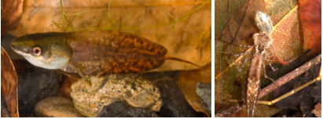

Treefrog tadpole and its predator, a dragonfly larva

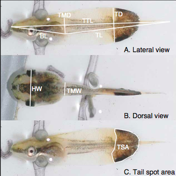

Morphological measurements made by Touchon and Warkentin (2008). Available data correspond to TD = tail fin depth.

Step 1: Import “tadpole” to RStudio and explore it

> **Question 1:** How many variables and what type of variables (e.g., categorical, continuous) “tadpole” has?

> **Question 2:** Given the type of variables available, what type of data visualization is more appropriate (type of graph)?

> **Group Challenge:** Knowing the structure of the available data, generate a testable hypothesis on the phenotypic plasticity of tadpoles raised in control conditions and in the presence of a dragonfly predator. Draw graphical representations on the wall. Include the null hypothesis.

Step 2: Explore the experiment results. The package “Rmisc” allows you to estimate descriptive statistics easily using the command summarySE(). Go ahead, install and load this package in R.

```r
install.packages("Rmisc",repos='http://cran.us.r-project.org')
library(Rmisc)
```

To get a summary of descriptive statistics (mean, SD, SE, 95%CI) use the function summarySE(). The first argument in this function is the dataframe’s name (tadpole), and the subsequent arguments are the column name of the variable to be summarized (dependent variable), followed by the column name containing the grouping variable (independent variable), all separated by commas. Remember that column names should go with " ".

Go ahead and estimate the summary statistics for “tadpole”.

> **Question 1:** What are the dependent and independent variables?

> **Question 2:** Is there variation within treatments? Explain.

> **Question 3:** What is the mean value of the dependent variable in each treatment?

> **Question 4:** Do the data seem to support your hypothesis?

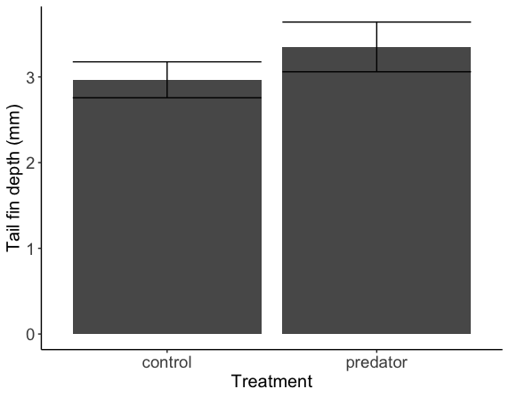

Step 3: Test your hypothesis

In science we cannot say a sample group is different from another without statistics. Today, you will perform a two-tailed t-test to determine whether there is a significant difference between the means of two groups, in this case the control vs predator groups.

A two-tailed t-test is used to test the difference between two means relative to the noise (variation) in the data. In other words it lets you know if those differences (measured in means/averages) could have happened by chance. The formula is below

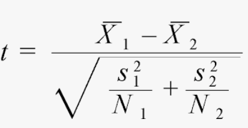

where X bar 1 and X bar 2 are the sample means of the two groups, S are the sample variances of the two groups, N1 and N2 are the sample sizes of the two groups and *t* is the student *t* score with N1 + N2 - 2 degrees of freedom.

**The *t* statistics:** Remember that the *t* score is a ratio of the difference between two groups and the difference *within* the groups. The larger the *t* score, the more difference there is between groups. For instance, a *t* score of 3 means that the groups are three times as different from each other as they are within each other.  
**The p-value:** Every *t*-value has a *p*-value to go with it. A *p*-value is the probability that the results from your sample data occurred by chance. *P*-values are from 0% to 100%. For example, a *p*-value of 5% (0.05) means that, given that the null hypothesis is true, there is a 5% chance of repeating the experiment and obtaining the same results. As 5% is very low, we can be confident of rejecting the null hypothesis (results are not probably by chance).  
The R function t.test() estimates a two-sample *t*-test. The first argument is the continuous variable and the second argument is the categorical variable (group variable), both separated by “~”.

Go ahead and estimate a t test.

```r
# t-test
t.test(tadpole$tail_fin_depth_mm~tadpole$treatment)
```

> **Question 1:** Interprete the estimated *t* ratio.

> **Group Challenge:** Read the R *t*-test output carefully to interprate it. Can you reject the null hypothesis? Explain.

**FIN**

**Great Work!**